# Physician Referral Networks

Ian McCarthy

September 2020

# 1 Starting off

To begin, let’s read in the final edge and node lists created with the _BuildFinalData.R code file, along with the 2010 physician shared patient data from SharedPatientData.R. Note that the edge list is taken directly from the shared patient data already, but the shared patient data is a more traditional dataframe with information about physicians in any given pair.

```r
edge_data <- readRDS("../data/edge_data.RData")
node_data <- readRDS("../data/node_data.RData")
edge_small <- readRDS("../data/edge_small.RData")
node_small <- readRDS("../data/node_small.RData")

pspd_data <- readRDS("../data/pspd_data.RData")
```

Before working with the networks, let’s get a sense of the types of specialists and physicians that made it to the final data. These specialists and their frequencies are listed in Table 1.1. Unfortunately, we see that the most commonly occurring specialist is simply “specialist”. We could try to get some more info there from the physician compare data, but this is enough for now. The top row here means that there are 761,249 connections between a primary care physician and simply “specialist” across the U.S. in 2010. This is out of 2,762,249 total PCP/specialist pairs throughout the country (including all specialists, not just those with a taxonomy description limited to “specialist”).

Table 1.1: Count of Specialists Receiving a Referral

| Taxonomy Code | Description | Count |
| --- | --- | --- |
| 174400000X | Specialist | 761,249 |
| 208600000X | Surgery | 366,389 |
| 208800000X | Urology | 311,235 |
| 213E00000X | Podiatrist | 273,090 |
| 207X00000X | Orthopaedic Surgery | 260,501 |
| 2086S0129X | Surgery Vascular Surgery | 166,642 |
| 213ES0103X | Podiatrist Foot Ankle Surgery | 123,401 |
| 207Y00000X | Otolaryngology | 111,500 |
| 208G00000X | Thoracic Surgery Cardiothoracic Vascular Surgery | 79,207 |
| 213ES0131X | Podiatrist Foot Surgery | 44,470 |
| 207T00000X | Neurological Surgery | 40,654 |
| 213EP1101X | Podiatrist Primary Podiatric Medicine | 27,132 |
| 207XX0005X | Orthopaedic Surgery Sports Medicine | 20,876 |
| 207XS0114X | Orthopaedic Surgery Adult Reconstructive Orthopaedic Surgery | 14,875 |
| 207XS0117X | Orthopaedic Surgery Orthopaedic Surgery of the Spine | 14,806 |
| 208C00000X | Colon Rectal Surgery | 13,273 |
| 2086S0102X | Surgery Surgical Critical Care | 11,163 |
| 207YX0905X | Otolaryngology Otolaryngology/Facial Plastic Surgery | 10,695 |
| 208200000X | Plastic Surgery | 10,435 |
| 207XS0106X | Orthopaedic Surgery Hand Surgery | 10,267 |
| 204F00000X | Transplant Surgery | 9,312 |
| 2086S0127X | Surgery Trauma Surgery | 8,236 |
| 204D00000X | Neuromusculoskeletal Medicine OMM | 6,809 |
| 207YX0007X | Otolaryngology Plastic Surgery within the Head Neck | 6,780 |
| 2086X0206X | Surgery Surgical Oncology | 6,638 |
| 204C00000X | Neuromusculoskeletal Medicine Sports Medicine | 6,113 |
| 2086S0122X | Surgery Plastic and Reconstructive Surgery | 5,196 |
| 207XX0004X | Orthopaedic Surgery Foot and Ankle Surgery | 4,712 |
| 207YS0123X | Otolaryngology Facial Plastic Surgery | 4,694 |
| 207XX0801X | Orthopaedic Surgery Orthopaedic Trauma | 4,675 |
| 207YX0602X | Otolaryngology Otolaryngic Allergy | 4,501 |
| 2088P0231X | Urology Pediatric Urology | 2,772 |
| 213ES0000X | Podiatrist Sports Medicine | 2,629 |
| 207YX0901X | Otolaryngology Otology Neurotology | 2,517 |
| 207YP0228X | Otolaryngology Pediatric Otolaryngology | 1,996 |
| 202K00000X | Phlebology | 1,699 |
| 2082S0105X | Plastic Surgery Surgery of the Hand | 1,428 |
| 2086S0105X | Surgery Surgery of the Hand | 1,253 |
| 213ER0200X | Podiatrist Radiology | 1,175 |
| 213EP0504X | Podiatrist Public Medicine | 1,166 |
| 204R00000X | Electrodiagnostic Medicine | 1,108 |
| 207YS0012X | Otolaryngology Sleep Medicine | 1,051 |
| 193400000X | Single Specialty | 813 |
| 2082S0099X | Plastic Surgery Plastic Surgery Within the Head and Neck | 758 |
| 2088F0040X | Urology Female Pelvic Medicine and Reconstructive Surgery | 512 |
| 207XP3100X | Orthopaedic Surgery Pediatric Orthopaedic Surgery | 456 |
| 204E00000X | Oral Maxillofacial Surgery | 345 |
| 193200000X | MultiSpecialty | 320 |
| 1744R1102X | Specialist Research Study | 211 |
| 2086H0002X | Surgery Hospice and Palliative Medicine | 211 |
| 2086S0120X | Surgery Pediatric Surgery | 172 |
| 1744G0900X | Specialist Graphics Designer | 117 |
| 1744P3200X | Specialist Prosthetics Case Management | 14 |

Let’s do the same thing for referring physicians, just to see the types of physicians I’m classifying as “primary care”. These physicians and frequencies are listed in Table 1.2. Again, the top row here means that 855,688 of all PCP/specialist connections are from a PCP classified as “internal medicine” doctors.

Table 1.2: Count of Referring Physicians

| Taxonomy Code | Description | Count |
| --- | --- | --- |
| 207R00000X | Internal Medicine | 855,688 |
| 207RC0000X | Internal Medicine Cardiovascular Disease | 616,779 |
| 207Q00000X | Family Medicine | 423,333 |
| 207RN0300X | Internal Medicine Nephrology | 138,544 |
| 207RG0100X | Internal Medicine Gastroenterology | 131,651 |
| 207RP1001X | Internal Medicine Pulmonary Disease | 107,962 |
| 207RH0003X | Internal Medicine Hematology Oncology | 81,788 |
| 207RI0011X | Internal Medicine Interventional Cardiology | 68,558 |
| 207RI0200X | Internal Medicine Infectious Disease | 64,942 |
| 207RC0200X | Internal Medicine Critical Care Medicine | 60,322 |
| 207RE0101X | Internal Medicine Endocrinology Diabetes Metabolism | 44,440 |
| 207RR0500X | Internal Medicine Rheumatology | 29,808 |
| 207RG0300X | Internal Medicine Geriatric Medicine | 29,484 |
| 207RC0001X | Internal Medicine Clinical Cardiac Electrophysiology | 23,369 |
| 208D00000X | General Practice | 22,517 |
| 207RX0202X | Internal Medicine Medical Oncology | 15,591 |
| 207QG0300X | Family Medicine Geriatric Medicine | 10,013 |
| 207RS0012X | Internal Medicine Sleep Medicine | 9,514 |
| 207QA0505X | Family Medicine Adult Medicine | 5,594 |
| 207RH0000X | Internal Medicine Hematology | 3,958 |
| 207RH0002X | Internal Medicine Hospice and Palliative Medicine | 2,619 |
| 207QS0010X | Family Medicine Sports Medicine | 2,598 |
| 207RA0000X | Internal Medicine Adolescent Medicine | 2,127 |
| 207RM1200X | Internal Medicine Magnetic Resonance Imaging MRI | 1,721 |
| 207QH0002X | Family Medicine Hospice and Palliative Medicine | 1,445 |
| 207RI0008X | Internal Medicine Hepatology | 1,387 |
| 207RA0401X | Internal Medicine Addiction Medicine | 1,121 |
| 207RA0201X | Internal Medicine Allergy Immunology | 942 |
| 207QA0401X | Family Medicine Addiction Medicine | 730 |
| 207QA0000X | Family Medicine Adolescent Medicine | 659 |
| 207RA0001X | Internal Medicine Advanced Heart Failure and Transplant Cardiology | 646 |
| 207RH0005X | Internal Medicine Hypertension Specialist | 593 |
| 207RS0010X | Internal Medicine Sports Medicine | 544 |
| 207QS1201X | Family Medicine Sleep Medicine | 413 |
| 207RB0002X | Internal Medicine Bariatric Medicine | 282 |
| 207RI0001X | Internal Medicine Clinical Laboratory Immunology | 272 |
| 207RT0003X | Internal Medicine Transplant Hepatology | 168 |
| 207RA0002X | Internal Medicine Adult Congenital Heart Disease | 101 |
| 207QB0002X | Family Medicine Bariatric Medicine | 26 |

Finally, before moving on to the network structure, let’s just summarize the numbers of shared patients we see in the data, along with a few other varialbes of interest. Table 1.3 presents the mean, standard deviation, min, and max for the following variables: 1) “PCP to specialist”, which measures the number of specialists to which a given PCP shares patients; 2) “Specialist from PCP”, which measures the number of PCPs from which a specialist receives patients; 3) “Patient visits”, measuring the number of visits among the shared patients between a given PCP/specialist pair; 4) “Same-day visits”, measuring the number of visits on the same day to both the PCP and specialist in a pair; and 5) “Unique patients”, which measures the number of patients shared between a given PCP and specialist (smaller than the number of visits, since the same patient may have multiple visits).

Table 1.3: Summary Statistics for Shared Patients

| Variable | Mean | Std. Dev. | Min | Max |
| --- | --- | --- | --- | --- |
| PCP to specialist | 35.98 | 32.09 | 1 | 585 |
| Specialist from PCP | 76.32 | 72.87 | 1 | 1,136 |
| Same-day visits | 5.15 | 19.47 | 0 | 4,554 |
| Patient visits | 197.89 | 364.85 | 11 | 120,230 |
| Unique patients | 27.38 | 31.08 | 11 | 2,329 |

One interesting takeaway from Table 1.3 is that PCPs have far fewer connections to individual specialists than specialists do with individual PCPs. Specifically, the average PCP shares patients with 36 different specialists, while the average specialist receives patients from 76 different PCPs.

# 2 Referral Networks

Now let’s take a look at the network structure of PCP referrals to specialist, focusing on shared patients among physicians in Atlanta, GA. For this, we’ll use the `igraph` and `ggraph` packages.

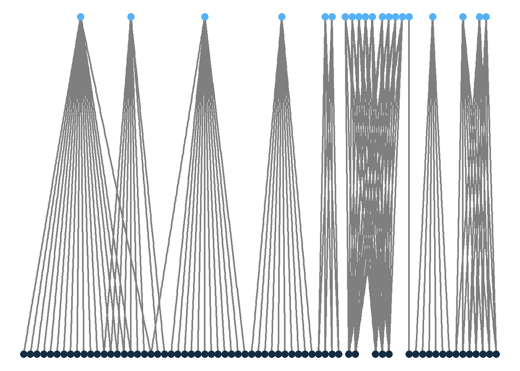